# Homework Assignment #2

Part II

Author

Benjamin Versteeg

Published

February 3, 2024

*Had to change data set due to a lack of data.*

## About the Dataset

This dataset contains a list of video games with sales greater than 100,000 copies. It was generated by a scrape of [vgchartz.com](http://www.vgchartz.com/).

Url: https://www.kaggle.com/datasets/gregorut/videogamesales/data

Variables in the dataset:

- Rank - Ranking of overall sales
- Name - The game’s name
- Platform - Platform of the games release (i.e. PC,PS4, etc.)
- Year - Year of the game’s release
- Genre - Genre of the game
- Publisher - Publisher of the game
- NA_Sales - Sales in North America (in millions)
- EU_Sales - Sales in Europe (in millions)
- JP_Sales - Sales in Japan (in millions)
- Other_Sales - Sales in the rest of the world (in millions)
- Global_Sales - Total worldwide sales.

```r
##~~~~~~~~~~~~~~~~~~~~~~~~~~~~~~~~~~~~~~~~~~~~~~~~~~~~~~~~~~~~~~~~~~~~~~~~~~~~~~
##                                load packages                             ----
##~~~~~~~~~~~~~~~~~~~~~~~~~~~~~~~~~~~~~~~~~~~~~~~~~~~~~~~~~~~~~~~~~~~~~~~~~~~~~~

library(tidyverse)
##~~~~~~~~~~~~~~~~~~~~~~~~~~~~~~~~~~~~~~~~~~~~~~~~~~~~~~~~~~~~~~~~~~~~~~~~~~~~~~
##                                import data                               ----
##~~~~~~~~~~~~~~~~~~~~~~~~~~~~~~~~~~~~~~~~~~~~~~~~~~~~~~~~~~~~~~~~~~~~~~~~~~~~~~

vgsales <- read_csv("data/vgsales.csv")
```

```r
##~~~~~~~~~~~~~~~~~~~~~~~~~~~~~~~~~~~~~~~~~~~~~~~~~~~~~~~~~~~~~~~~~~~~~~~~~~~~~~
##                          data cleaning & wrangling                       ----
##~~~~~~~~~~~~~~~~~~~~~~~~~~~~~~~~~~~~~~~~~~~~~~~~~~~~~~~~~~~~~~~~~~~~~~~~~~~~~~

vgsales_clean <- vgsales %>%
  janitor::clean_names() %>% # Cleans column names
  filter(year <= 2017) # Filters to 2017 and before bc it removes the NA values and an unnessary data point
```

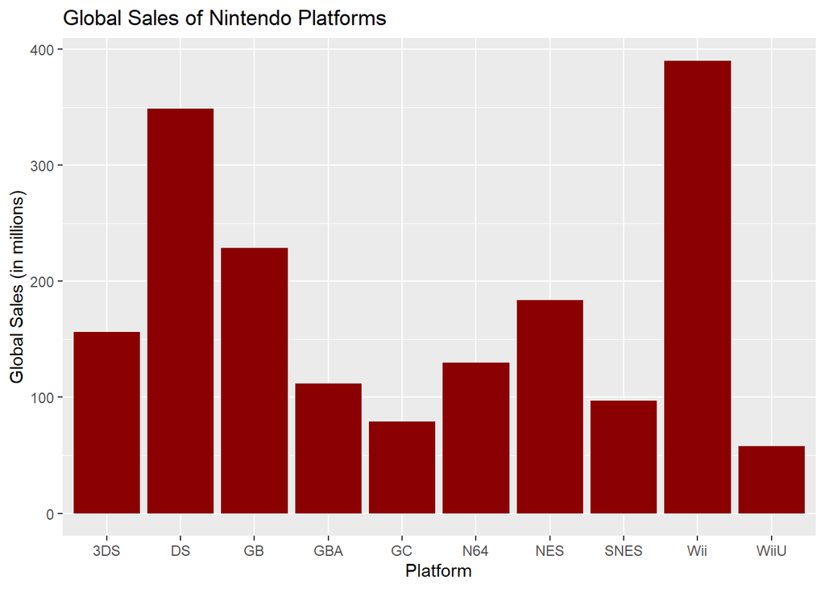

```r
##~~~~~~~~~~~~~~~~~~~~~~~~~~~~~~~~~~~~~~~~~~~~~~~~~~~~~~~~~~~~~~~~~~~~~~~~~~~~~~
##                                  plot #1                                 ----
##~~~~~~~~~~~~~~~~~~~~~~~~~~~~~~~~~~~~~~~~~~~~~~~~~~~~~~~~~~~~~~~~~~~~~~~~~~~~~~

# Create a bar plot
vgsales_clean %>%
  filter(publisher == "Nintendo") %>% # Filters to Nintendo publisher
  ggplot(aes(x = platform, y = global_sales)) +
  geom_bar(stat = "identity", fill = "darkred") + # Bar Plot
  labs(title = "Global Sales of Nintendo Platforms", # Title
       x = "Platform", # X-axis Label
       y = "Global Sales (in millions)") # Y-axis Label
```

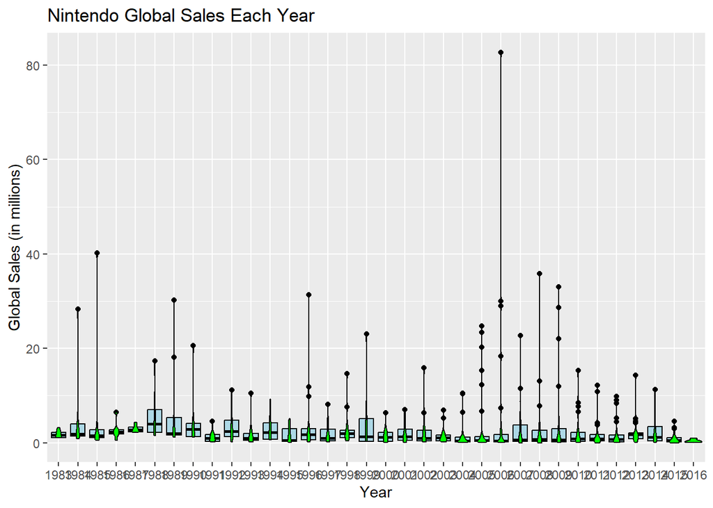

```r
##~~~~~~~~~~~~~~~~~~~~~~~~~~~~~~~~~~~~~~~~~~~~~~~~~~~~~~~~~~~~~~~~~~~~~~~~~~~~~~
##                                  plot #2                                 ----
##~~~~~~~~~~~~~~~~~~~~~~~~~~~~~~~~~~~~~~~~~~~~~~~~~~~~~~~~~~~~~~~~~~~~~~~~~~~~~~

vgsales_clean %>%
  filter(publisher == "Nintendo") %>% # Filters to Nintendo publisher
ggplot(aes(x = year, y = global_sales)) +
  geom_boxplot(fill = "lightblue", color = "black") + # Box plot
  geom_violin(fill = "green", color = "black") + # Voilin plot
  labs(title = "Nintendo Global Sales Each Year", # Title
       x = "Year", # X-axis Label
       y = "Global Sales (in millions)") # Y-axis Label
```

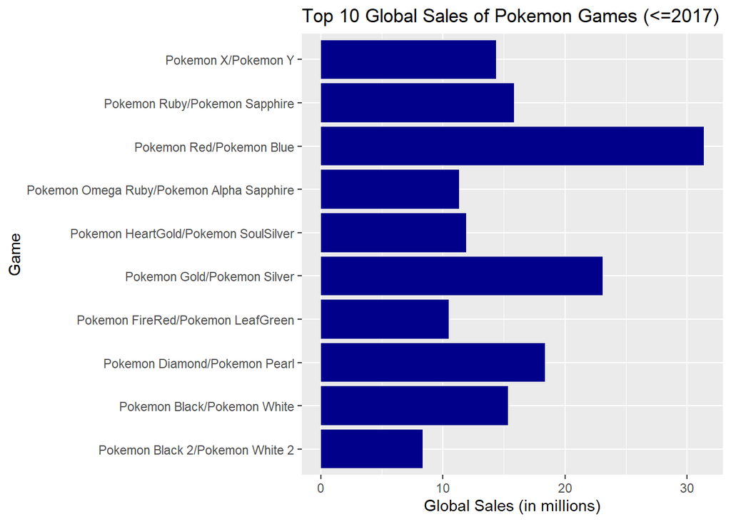

```r
##~~~~~~~~~~~~~~~~~~~~~~~~~~~~~~~~~~~~~~~~~~~~~~~~~~~~~~~~~~~~~~~~~~~~~~~~~~~~~~
##                                  plot #3                                 ----
##~~~~~~~~~~~~~~~~~~~~~~~~~~~~~~~~~~~~~~~~~~~~~~~~~~~~~~~~~~~~~~~~~~~~~~~~~~~~~~

# Create a bar plot
vgsales_clean %>%
  filter(grepl("pokemon", tolower(name))) %>% # Filters to Pokemon games
  head(10) %>% # Only keeps top 10 rows
  ggplot(aes(x = name, y = global_sales)) +
  geom_bar(stat = "identity", fill = "darkblue") + # Bar Plot
  labs(title = "Top 10 Global Sales of Pokemon Games (<=2017)", # Title
       x = "Game", # X-axis label
       y = "Global Sales (in millions)") + # Y-axis label
  coord_flip() # flips graph
```

# Questions

#### 1. What have you learned about your data? Have any potentially interesting patterns emerged? (5-8 sentences)

With this data set, I learned that a lot of filtering is better when analyzing this data. Instead of looking at all companies or all games, filtering the data to only include specifics makes the output less cluttered. Looking at a lot of the data at once is vary clustered and varied because of the immense amount of data. The outputs for each of the plots I could have predicted considering my prior knowledge with video game popularity however I was surprised how terrible the Wii U performed compared to other Nintendo platforms. I knew it didn’t do that well as a console but never expected it to have the worst sales.

#### 2. In HW #1, you outlined some questions that you wanted to answer using these data. Have you made any strides towards answering those questions? If yes, how so? If no, what next steps do you need to take (e.g. I need to create X plot type, I still need to track down Y data, I need to restructure existing data so that you can visualize it in Z ways, etc.)? (8-12 sentences)

Unfortunately, I had to pick a new data set because the previous data I chose lacked things I could visualize. However, some questions I wanted to answer when I picked this data set was:

- How do different video game companies compare to each other in terms of quantity games and total global sales?
- How do the different Nintendo platforms compare to each other (genre, global sales)?
- Which games had the most sales in specific gaming series (Pokemon, Mario, Zelda)?
- How do the biggest games compare to each other?

I was able to make some steps to answer these questions when analyzing the data. I got to look at a comparison between top 10 pokemon games as well as Nintendo platforms. I still need to look into more specific gaming series, compare video game companies, and compare the biggest selling games. I feel pretty confident I am able to accomplish all of these tasks.

#### 3. What challenges do you foresee encountering with your data? These can be data wrangling and / or visualization challenges. (4-6 sentences)

I think a big challenge with this data is being able to clearly visualize a mass amount of information. There is a lot of data in the data set and being able to show what I want without the graphs being cluttered or messy will be hard. The box/violin plot I made is an example of how working with this data is challenging. There’s a lot of variability so unless I focus on specific things, the plots tend to end up super zoomed out and makes it impossible to understand anything.

Figure for discussion

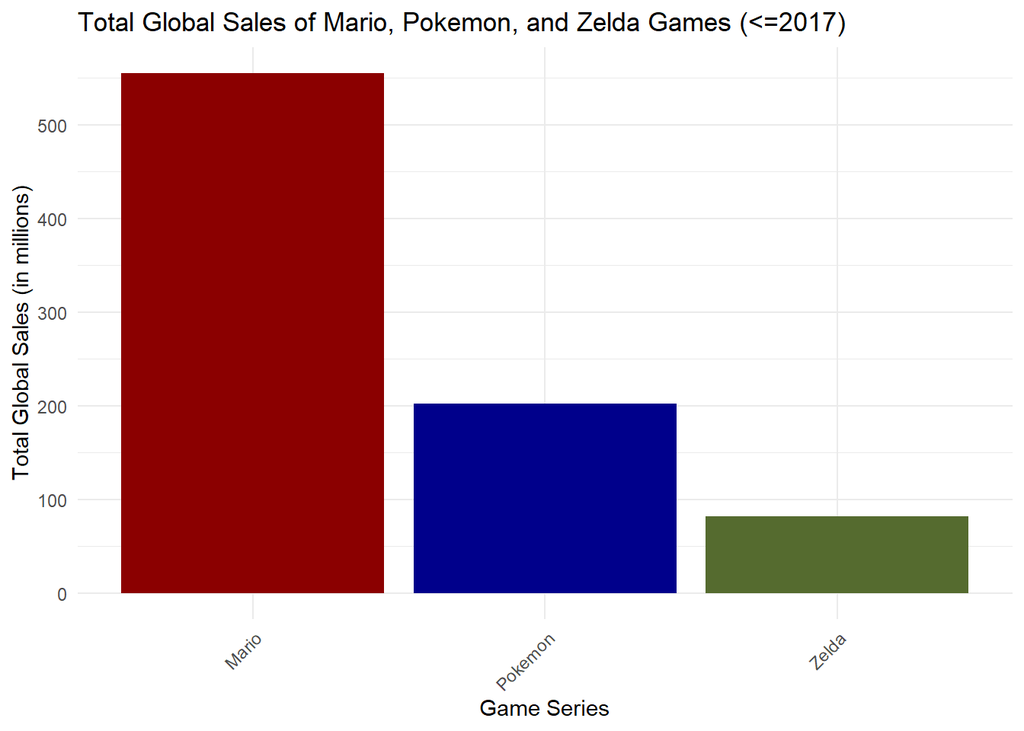

```r
vgsales_clean %>%
  filter(grepl("pokemon|zelda|mario", tolower(name))) %>% # Filters to Pokemon, Zelda, and Mario games
  mutate(series = case_when(
    grepl("mario", tolower(name)) ~ "Mario",
    grepl("zelda", tolower(name)) ~ "Zelda",
    grepl("pokemon", tolower(name)) ~ "Pokemon")) %>%
  group_by(series) %>%
  summarise(total_sales = sum(global_sales)) %>%
  ggplot(aes(x = series, y = total_sales, fill = series)) +
  geom_bar(stat = "identity") +
  labs(title = "Total Global Sales of Mario, Pokemon, and Zelda Games (<=2017)",
       x = "Game Series",
       y = "Total Global Sales (in millions)") +
  theme_minimal() +
  theme(axis.text.x = element_text(angle = 45, hjust = 1)) +
  scale_fill_manual(values = c("Mario" = "darkred", "Zelda" = "darkolivegreen", "Pokemon" = "darkblue")) +
  scale_y_continuous(labels = scales::comma, breaks = seq(0, 600, by = 100)) +
  theme(legend.position = "none")
```